# Covid 19 project

2022-04-24

# Covid-19 cases and evolution.

## How did the cases and lethality of Covid-19 behaved worldwide and which Countries had the highest amount of cases?

```r
library(tidyverse)
library(lubridate)
library(ggplot2)
library(patchwork) #to display to plots together
```

## Import the data sets.

We load the data of covid-19 cases and deaths from the John Hopkins github Covid-19 Repository. https://github.com/CSSEGISandData/COVID-19.

```r
url_in <- "https://raw.github.com/CSSEGISandData/COVID-19/master/csse_covid_19_data/csse_covid_19_time_series/"
file_names <- c("time_series_covid19_confirmed_global.csv","time_series_covid19_deaths_global.csv",
                "time_series_covid19_confirmed_US.csv","time_series_covid19_deaths_US.csv")

urls <- str_c(url_in,file_names)
global_cases <- read_csv(urls[1])
global_deaths <- read_csv(urls[2])
us_cases <- read_csv(urls[3])
us_deaths <- read_csv(urls[4])
```

We load the population data for the countries in the global database. Such data also comes from the John Hopkins repository.

```r
url_UID <- "https://raw.github.com/CSSEGISandData/COVID-19/master/csse_covid_19_data/UID_ISO_FIPS_LookUp_Table.csv"
uid <- read_csv(url_UID)
#Keep only what we care about
uid <- uid %>%
  select(-c(Lat,Long_,Combined_Key))
```

## Data Cleaning

First we pivot the data frames to have a column of dates. Instead of a column for each date.

```r
#Pivot the data to a more convenient format
global_cases <- global_cases %>%
  pivot_longer(cols = -c(`Province/State`,`Country/Region`, `Lat`,`Long`),
               names_to = "date",
               values_to = "cases") %>%
  select(-c(Lat,Long))

global_deaths <- global_deaths %>%
  pivot_longer(cols = -c(`Province/State`,`Country/Region`, `Lat`,`Long`),
               names_to = "date",
               values_to = "deaths") %>%
  select(-c(Lat,Long))


us_cases <- us_cases %>%
  pivot_longer(cols = -c("UID","iso2","iso3","code3","FIPS","Admin2",
                         "Province_State", "Country_Region", "Lat" , "Long_", "Combined_Key"),
               names_to = "date",
               values_to = "cases") %>%
  select(-c(Lat,Long_))

us_deaths <- us_deaths %>%
  pivot_longer(cols = -c("UID","iso2","iso3","code3","FIPS","Admin2", "Province_State",
                         "Country_Region", "Lat" , "Long_", "Combined_Key", "Population"),
               names_to = "date",
               values_to = "deaths") %>%
  select(-c(Lat,Long_))
```

We join the global data in one data frame and add the population data, and the US data in another data frame. And check the summary of each data frame to get a general idea of how the data looks and if we need to do any more cleaning.

```r
#Put all the data in a global dataframe, fix the date format and add new column of combined Key
global <- global_cases %>%
  full_join(global_deaths) %>%
  rename(`Country_Region`= `Country/Region`,
         `Province_State` = `Province/State`) %>%
  mutate(date = mdy(date)) %>%
  unite("Combined_Key", c(Province_State, Country_Region),
        sep = ", ", na.rm = TRUE, remove = FALSE)
global <- global %>%
  left_join(uid, by = c("Province_State", "Country_Region")) %>%
  select(-c(UID,FIPS))%>%
  select(Province_State, Country_Region, date, cases, deaths, Population, Combined_Key)

#If both cases and deads for a given row are zero we get rid of such rows.
global <- global[!(global$cases==0 & global$deaths==0),]



summary(global)
```

```
##  Province_State     Country_Region          date                cases
##  Length:216371      Length:216371      Min.   :2020-01-22   Min.   :       0
##  Class :character   Class :character   1st Qu.:2020-09-19   1st Qu.:     653
##  Mode  :character   Mode  :character   Median :2021-04-04   Median :    9308
##                                        Mean   :2021-04-01   Mean   :  570820
##                                        3rd Qu.:2021-10-16   3rd Qu.:  140528
##                                        Max.   :2022-04-25   Max.   :81043315
##
##      deaths         Population        Combined_Key
##  Min.   :     0   Min.   :8.090e+02   Length:216371
##  1st Qu.:     4   1st Qu.:8.696e+05   Class :character
##  Median :   121   Median :7.203e+06   Mode  :character
##  Mean   : 10712   Mean   :2.935e+07
##  3rd Qu.:  2286   3rd Qu.:2.983e+07
##  Max.   :991609   Max.   :1.380e+09
##                   NA's   :4918
```

```r
usa <- us_cases %>%
  full_join(us_deaths)%>%
  mutate(date = mdy(date))
```

[output not shown]

```r
usa <- usa[!(usa$cases==0 & usa$deaths==0),]

summary(usa)
```

```
##       UID               iso2               iso3               code3
##  Min.   :      16   Length:2445897     Length:2445897     Min.   : 16.0
##  1st Qu.:84018063   Class :character   Class :character   1st Qu.:840.0
##  Median :84029115   Mode  :character   Mode  :character   Median :840.0
##  Mean   :83445836                                         Mean   :834.7
##  3rd Qu.:84045081                                         3rd Qu.:840.0
##  Max.   :84099999                                         Max.   :850.0
##
##       FIPS          Admin2          Province_State     Country_Region
##  Min.   :   60   Length:2445897     Length:2445897     Length:2445897
##  1st Qu.:19027   Class :character   Class :character   Class :character
##  Median :30033   Mode  :character   Mode  :character   Mode  :character
##  Mean   :31941
##  3rd Qu.:46137
##  Max.   :99999
##  NA's   :7503
##  Combined_Key            date                cases           Population
##  Length:2445897     Min.   :2020-01-22   Min.   :      0   Min.   :       0
##  Class :character   1st Qu.:2020-10-08   1st Qu.:    356   1st Qu.:   11085
##  Mode  :character   Median :2021-04-14   Median :   1701   Median :   26404
##                     Mean   :2021-04-13   Mean   :   9686   Mean   :  105301
##                     3rd Qu.:2021-10-19   3rd Qu.:   5690   3rd Qu.:   68412
##                     Max.   :2022-04-25   Max.   :2864284   Max.   :10039107
##
##      deaths
##  Min.   :    0.0
##  1st Qu.:    5.0
##  Median :   30.0
##  Mean   :  154.1
##  3rd Qu.:   96.0
##  Max.   :31938.0
##
```

We see that some rows in the global data frame dont have the population, so we take a look into what is such data. We look at the Combined key of the NA data

```r
na_pop <- global[is.na(global$Population),]

max_date <- na_pop%>%
  group_by(Combined_Key,Country_Region) %>%
  summarize(date = max(date)) %>%
  ungroup()
max_date<- left_join(max_date,na_pop, by = c('date','Combined_Key','Country_Region')) %>%
  select(c('Country_Region','Combined_Key','date','cases','deaths'))

max_date
```

```
## # A tibble: 9 × 5
##   Country_Region       Combined_Key                   date        cases deaths
##   <chr>                <chr>                          <date>      <dbl>  <dbl>
## 1 Antarctica           Antarctica                     2022-04-25     11      0
## 2 Diamond Princess     Diamond Princess               2022-04-25    712     13
## 3 Canada               Diamond Princess, Canada       2022-04-25      0      1
## 4 Canada               Grand Princess, Canada         2022-04-25     13      0
## 5 MS Zaandam           MS Zaandam                     2022-04-25      9      2
## 6 Canada               Repatriated Travellers, Canada 2022-04-25     13      0
## 7 Summer Olympics 2020 Summer Olympics 2020           2022-04-25    865      0
## 8 China                Unknown, China                 2022-04-25 635658      0
## 9 Winter Olympics 2022 Winter Olympics 2022           2022-04-25    535      0
```

The number of cases in most of them are very small compared to rest of the data and with the exception of the unkown, China is hard to add to a country in particular as they are cruises, or international events. So I will only keep the info of China from this data frame. As it says unknown for the province my guess is that are registered cases in china of traveling people or something like that, so if we want to see china as a whole we can add this cases, if we want to see it by province we wouldn’t take it into account.

```r
global <-global[!(is.na(global$Population) & global$Country_Region!="China"),]
```

I will add a couple of new variables related to the date, days since the pandemic started and weeks since the pandemic started.

```r
#We get the number of days since the first record in our dates.

#This gives the number of days between 1970-01-01 and the first record in our data
first_record = as.numeric(min(global$date))
#Subtracting it we can get how many days into the pandemic each date is, or how many days after the data recorsd started apparently on January 22 2020. Using this info we can get how many weeks into the pandemic. The first 7 days would correspond to the first week days 8 to 14 to the second week and so on.

global <- global %>%
  mutate(days_p = as.numeric(date)-first_record+1)%>%
  mutate(weeks_p = trunc((days_p-1)/7)+1)
```

## Some graphs to visualize the data.

Now the data is tidier we can see some visualization, such as how the number of worldwide cases and deaths have increased since the beginning of the pandemic. I will use a log plot to have a better idea of whats going on.

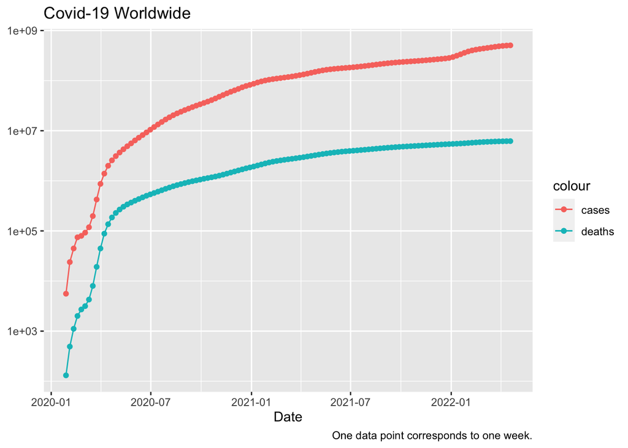

```r
global_country<- global %>%
  group_by(Country_Region, date, weeks_p, days_p) %>%
  summarize(Cases = sum(cases), Deaths = sum(deaths), Population = sum(Population, na.rm = TRUE)) %>%
  mutate(cases_per_mill = Cases/Population*1000000, deaths_per_mill = Deaths/Population*1000000)%>%
  ungroup()

total_w = global %>%
  group_by(date, weeks_p, days_p) %>%
  summarize(Cases = sum(cases), Deaths = sum(deaths), Population = sum(Population, na.rm = TRUE)) %>%
  mutate(cases_per_mill = Cases/Population*1000000, deaths_per_mill = Deaths/Population*1000000)%>%
  ungroup()
#Keep only data of the end of each week, or weekly data
w_total_w = total_w[total_w$days_p/7==total_w$weeks_p,]
w_global_country = global_country[(global_country$days_p/7==global_country$weeks_p),]

ggplot(w_total_w, aes(x= date, y = Cases)) +
  geom_point(aes(colour = "cases"))+
  geom_line(aes(colour = "cases")) +
  geom_point(aes( y= Deaths, colour = "deaths")) +
  geom_line(aes( y= Deaths, colour = "deaths")) +
  scale_y_log10() +
  labs(title = "Covid-19 Worldwide", y = NULL, x = "Date" ,caption = "One data point corresponds to one week.")
```

Which is the Country with more cases and how was the time evolution?

```r
global_country[global_country$Cases == max(global_country$Cases),]
```

```
## # A tibble: 1 × 9
##   Country_Region date       weeks_p days_p    Cases Deaths Population
##   <chr>          <date>       <dbl>  <dbl>    <dbl>  <dbl>      <dbl>
## 1 US             2022-04-25     118    825 81043315 991609  329466283
## # … with 2 more variables: cases_per_mill <dbl>, deaths_per_mill <dbl>
```

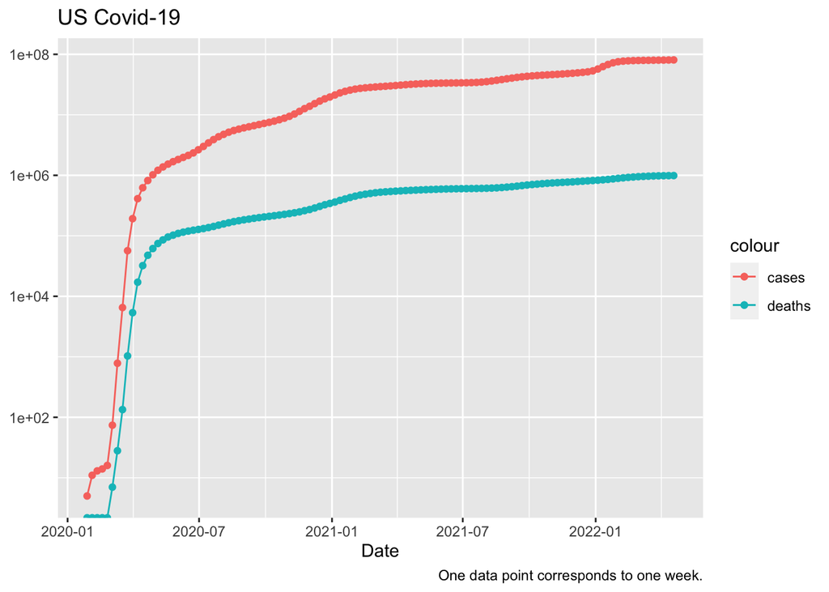

```r
max_c = global_country[global_country$Cases == max(global_country$Cases),]$Country_Region

ggplot(w_global_country[w_global_country$Country_Region == max_c,],aes(x= date, y = Cases)) +
  geom_point(aes(colour = "cases"))+
  geom_line(aes(colour = "cases")) +
  geom_point(aes( y= Deaths, colour = "deaths")) +
  geom_line(aes( y= Deaths, colour = "deaths")) +
  scale_y_log10() +
  labs(title =  paste(max_c, "Covid-19"), y = NULL , x = "Date" ,caption = "One data point corresponds to one week.")
```

## Some basic data Analysis

We look now at new weekly cases and new weekly deaths both worldwide and in the US. We look at the data weekly to avoid having noise because of reporting delays. This plot wont be on logarithmic scale, so to be able to see both the new cases and new deaths in the same figure I will use two different Y axis. Just to say keep in mind that in the next figure the new cases and new dead are in different scales.

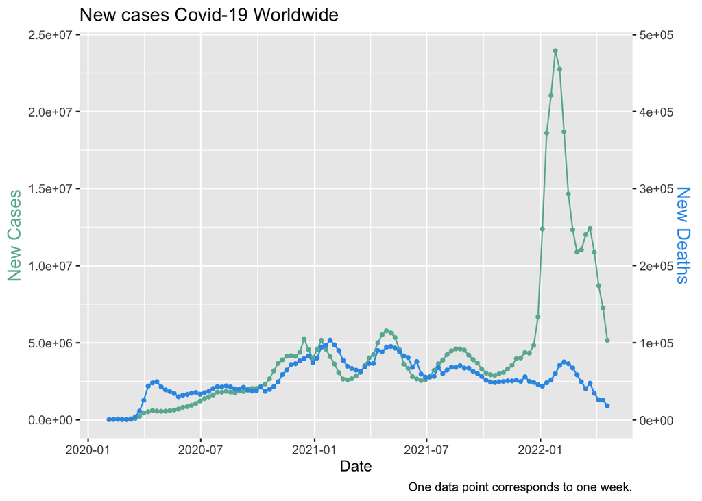

```r
w_global_country <- w_global_country %>%
  group_by(Country_Region)%>%
  mutate(new_cases = Cases- lag(Cases),
         new_deaths = Deaths - lag(Deaths))%>%
  ungroup()

w_total_w = w_total_w %>%
  mutate(new_cases = Cases- lag(Cases), new_deaths = Deaths - lag(Deaths))


# Value used to transform the data
coeff <- 50

# A few constants
newcasesColor <- "#69b3a2"
newdeathsColor <- rgb(0.2, 0.6, 0.9, 1)

ggplot(w_total_w, aes(x= date)) +
  geom_point( aes(y=new_cases),size = 1, color=newcasesColor) +
  geom_line( aes(y=new_cases), color=newcasesColor) +
  geom_point( aes(y=new_deaths *coeff),size = 1,  color=newdeathsColor) +
  geom_line( aes(y=new_deaths *coeff),  color=newdeathsColor) +
  scale_y_continuous(

    # Features of the first axis
    name = "New Cases",

    # Add a second axis and specify its features
    sec.axis = sec_axis(~.*1/coeff, name="New Deaths")
  ) +


  theme(
    axis.title.y = element_text(color = newcasesColor, size=13),
    axis.title.y.right = element_text(color = newdeathsColor, size=13)
  )   +labs(title = "New cases Covid-19 Worldwide",x = "Date" ,caption = "One data point corresponds to one week.")
```

We repeat the visualization for the US

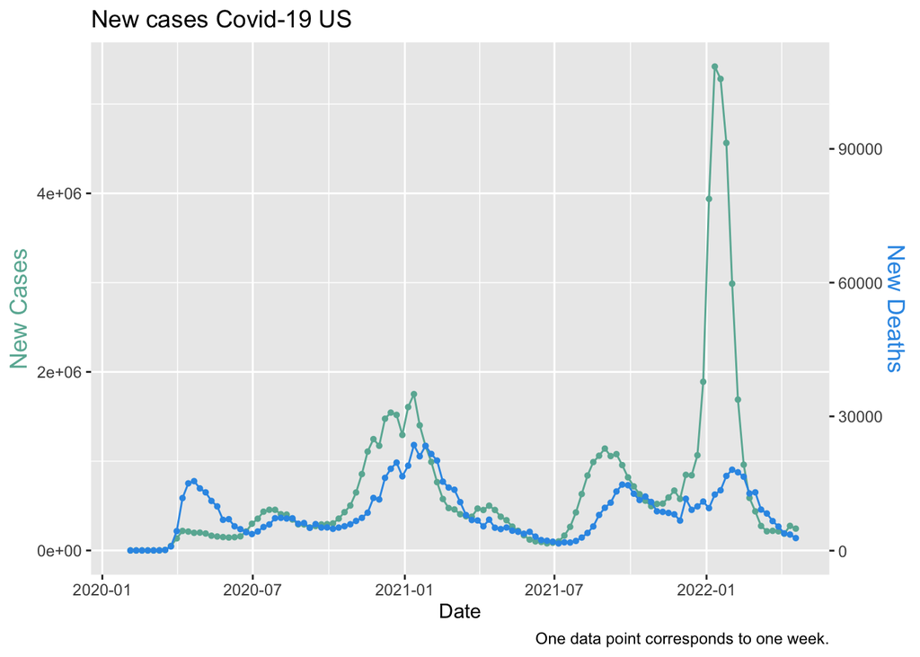

```r
ggplot(w_global_country[w_global_country$Country_Region == max_c,], aes(x= date)) +
  geom_point( aes(y=new_cases),size = 1, color=newcasesColor) +
  geom_line( aes(y=new_cases), color=newcasesColor) +
  geom_point( aes(y=new_deaths *coeff),size = 1,  color=newdeathsColor) +
  geom_line( aes(y=new_deaths *coeff),  color=newdeathsColor) +
  scale_y_continuous(

    # Features of the first axis
    name = "New Cases",

    # Add a second axis and specify its features
    sec.axis = sec_axis(~.*1/coeff, name="New Deaths")
  ) +


  theme(
    axis.title.y = element_text(color = newcasesColor, size=13),
    axis.title.y.right = element_text(color = newdeathsColor, size=13)
  )   +labs(title = paste("New cases Covid-19",max_c)  ,x = "Date" ,caption = "One data point corresponds to one week.")
```

On both the World and the US graph we can see that at the beginning of the pandemic the new deaths were higher compared with the number of new cases, while in the last wave, the number of new deaths decreased in comparison with the number of new cases. So we can say that the virus has become less deadly. This graphs does not give us the information of why this change happened. I think its because vaccines works, so we have become more resistant to the virus. I recognize my bias here, as I know vaccines safe lives, but as I am not using any vaccination data in this analysis, I can’t conclude from the data that the mortality decreased in part because of the vaccines.

On the lethality topic I will take a look at the mortality per millions.

### In which countries has Covid_19 been more deadly and less deadly.

Will just look at the Countries with more death per Million, and less death per million by looking at the current dates.

```r
current <- global_country[global_country$date==max(global_country$date),]

slice(arrange(current,desc(deaths_per_mill)) %>%
  select(-c('date','weeks_p','days_p')), 1:10)
```

```
## # A tibble: 10 × 6
##    Country_Region         Cases Deaths Population cases_per_mill deaths_per_mill
##    <chr>                  <dbl>  <dbl>      <dbl>          <dbl>           <dbl>
##  1 Peru                  3.56e6 212761   32971846        108022.           6453.
##  2 Bulgaria              1.15e6  36856    6948445        166009.           5304.
##  3 Bosnia and Herzegovi… 3.77e5  15762    3280815        114862.           4804.
##  4 Hungary               1.89e6  46101    9660350        196088.           4772.
##  5 North Macedonia       3.09e5   9276    2083380        148417.           4452.
##  6 Montenegro            2.35e5   2713     628062        373785.           4320.
##  7 Georgia               1.65e6  16800    3989175        414701.           4211.
##  8 Croatia               1.12e6  15790    4105268        272290.           3846.
##  9 Czechia               3.90e6  40102   10708982        364031.           3745.
## 10 Slovakia              2.52e6  19852    5434712        463921.           3653.
```

And the 10 countries with less death per million

```r
current <- global_country[global_country$date==max(global_country$date),]

slice(arrange(current,deaths_per_mill) %>%
  select(-c('date','weeks_p','days_p')), 1:10)
```

```
## # A tibble: 10 × 6
##    Country_Region     Cases Deaths Population cases_per_mill deaths_per_mill
##    <chr>              <dbl>  <dbl>      <dbl>          <dbl>           <dbl>
##  1 Holy See              29      0        809        35847.             0
##  2 Marshall Islands      17      0      58413          291.             0
##  3 Micronesia             3      0     113815           26.4            0
##  4 Burundi            39632     38   11890781         3333.             3.20
##  5 China            2041627  14043 1417925054         1440.             9.90
##  6 Chad                7411    193   16425859          451.            11.7
##  7 South Sudan        17443    138   11193729         1558.            12.3
##  8 Niger               8916    309   24206636          368.            12.8
##  9 Tajikistan         17786    125    9537642         1865.            13.1
## 10 Tanzania           33864    803   59734213          567.            13.4
```

For the results of countries of least and most mortality per million, we should keep in mind there is some bias in the data as each country reports differently. Some countries might only record covid deaths for hospital patients that had a positive covid test, while other countries might record any excess deaths as covid deaths. There is not a universal reporting system.

Given that Peru is the Country with the highest deaths per millions, lets take a look at Peru’s new cases and new deaths evolution, but this time in a logarithmic plot.

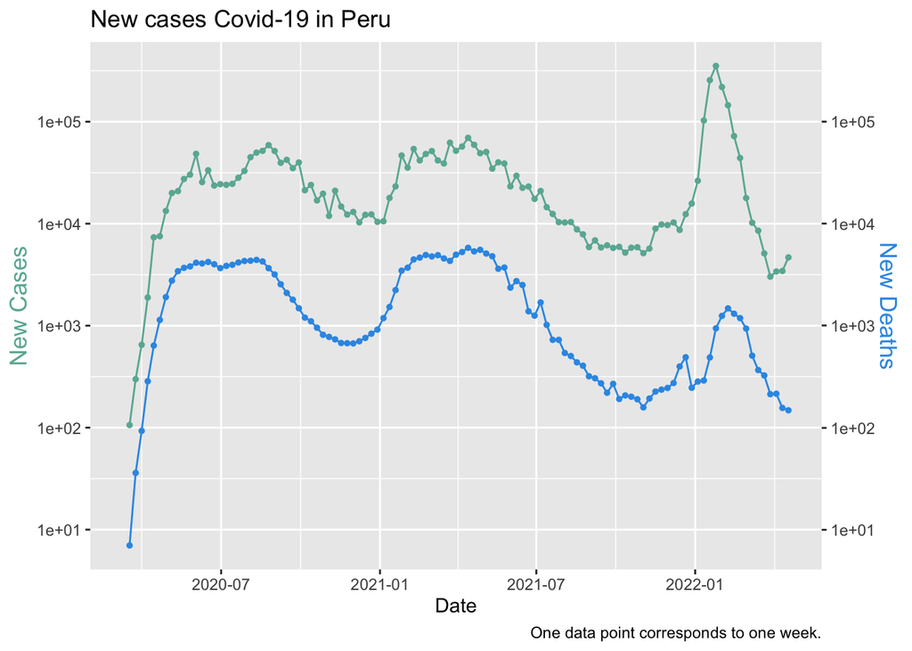

```r
    coeff = 1

peru <- w_global_country[w_global_country$Country_Region == "Peru",]
ggplot(peru, aes(x= date)) +
  geom_point( aes(y=new_cases),size = 1, color=newcasesColor) +
  geom_line( aes(y=new_cases), color=newcasesColor) +
  geom_point( aes(y=new_deaths *coeff),size = 1,  color=newdeathsColor) +
  geom_line( aes(y=new_deaths *coeff),  color=newdeathsColor) +
  scale_y_log10(

    # Features of the first axis
    name = "New Cases",
    # Add a second axis and specify its features
    sec.axis = sec_axis(~.*1/coeff, name="New Deaths")
  ) +


  theme(
    axis.title.y = element_text(color = newcasesColor, size=13),
    axis.title.y.right = element_text(color = newdeathsColor, size=13)
  )   +labs(title = paste("New cases Covid-19 in Peru")  ,x = "Date" ,caption = "One data point corresponds to one week.")
```

## A very simple model.

I will just look at a linear model on the deaths per Million in Peru based on the cases per million. First lets check at how the plot between those twoo and the color of the dot will reflect the week of the pandemic.

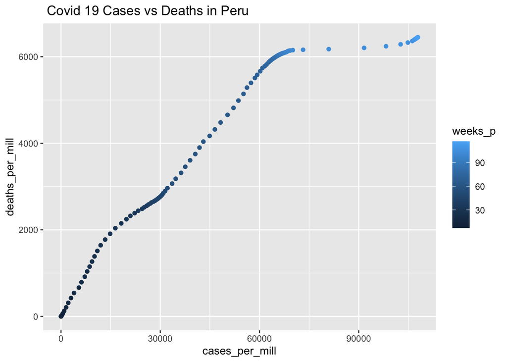

```r
ggplot(peru, aes(x =cases_per_mill,y = deaths_per_mill,colour = weeks_p))  +
  geom_point()  + labs(title= " Covid 19 Cases vs Deaths in Peru ")
```

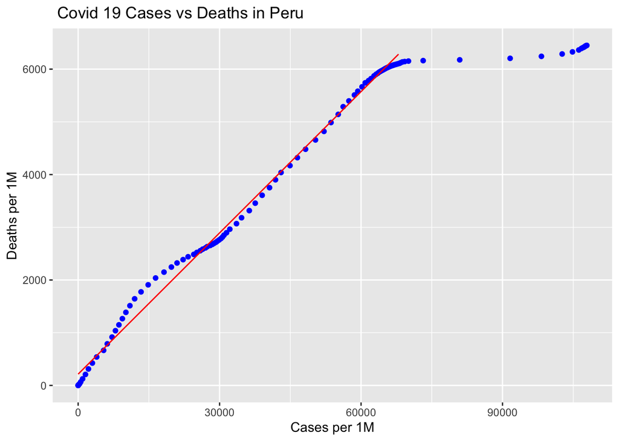

```r
#Make the model
mod = lm(deaths_per_mill~cases_per_mill, data = peru,subset = weeks_p<90)
xmod = seq(min(peru$cases_per_mill), 68000,50)
predic = data.frame(xm = xmod,ym = mod$coefficients[1]+xmod*mod$coefficients[2]  )
ggplot(peru, aes(x =cases_per_mill,y = deaths_per_mill))  +
  geom_point(color = "blue") +geom_line(color='red',data = predic, aes(x=xm, y=ym)) +labs(title= " Covid 19 Cases vs Deaths in Peru ", x= "Cases per 1M", y = "Deaths per 1M")
```

In the first 90 weeks of the pandemic in Peru a linear model fits the data. But after that its not longer linear. The details of the linear model are:

```r
summary(mod)
```

```
##
## Call:
## lm(formula = deaths_per_mill ~ cases_per_mill, data = peru, subset = weeks_p <
##     90)
##
## Residuals:
##     Min      1Q  Median      3Q     Max
## -214.19 -102.71  -25.91   59.88  368.98
##
## Coefficients:
##                 Estimate Std. Error t value Pr(>|t|)
## (Intercept)    2.141e+02  2.886e+01   7.419 1.04e-10 ***
## cases_per_mill 8.932e-02  7.181e-04 124.387  < 2e-16 ***
## ---
## Signif. codes:  0 '***' 0.001 '**' 0.01 '*' 0.05 '.' 0.1 ' ' 1
##
## Residual standard error: 147.1 on 81 degrees of freedom
## Multiple R-squared:  0.9948, Adjusted R-squared:  0.9947
## F-statistic: 1.547e+04 on 1 and 81 DF,  p-value: < 2.2e-16
```

## Conclusions

We looked at the worldwide evolution of Covid-19 and found that the Country with the most cases is the USA. When we looked at how the new cases and new deas changed we saw that at the begginig of the pandemic the virus was deadlier an as it evolved and as a society learned more about it, the new deaths went down when comparing them with the new cases, in the last wave of the virus in the first couple of months of 2022 there was a steep increase in the cases but not in the deaths. Finally we looked at the country with the most deths per million and found there was a linear relation between the cases per million and deaths per million in the first 90 weeks of the pandemic.

There is bias in the way each country collects their cases and deaths data.